# Number of Lifetime Sexual Partners

*[Disclaimer]* Originally, the sexual partner variables were added post hoc to the data set used in all previous analyses. However, for the simulated data set, they are already included. Thus, if you want to replicate the code below, select “fulldata_selected” instead of “fulldata_selected_pus_sexual_partner_variable” to load data with the sexual partner variable.

## Library

```r
library(ggplot2)
library(dplyr)
library(effsize)
```

## Load data

```r
# load data_prefs and data_self
data_rel = read.csv(file = "data/data_rel.csv")[,-1]
data_prefs = read.csv(file = "data/data_prefs.csv")[,-1]
data_self = read.csv(file = "data/data_self.csv")[,-1]

# load data with lifetime sexual partners variable
fulldata_selected_plus_sexual_partner_variable = read.csv(file = "data/fulldata_selected_plus_sexual_partner_variable.csv")[,-1]
names(fulldata_selected_plus_sexual_partner_variable)
```

```
##  [1] "sexual_orientation"            "country"
##  [3] "language"                      "age"
##  [5] "sex"                           "transgender"
##  [7] "relationship"                  "relationship1"
##  [9] "relationship2"                 "relationship3"
## [11] "relationship4"                 "relationship5"
## [13] "relationship_length"           "marital_status"
## [15] "political_spectrum"            "longest_relationship"
## [17] "self_kind"                     "self_supportive"
## [19] "self_attractive_body"          "self_attractive_face"
## [21] "self_financially_secure"       "self_successful_ambitous"
## [23] "self_confident"                "self_assertive"
## [25] "self_intelligence"             "self_educated"
## [27] "self_parenting"                "self_sexually_experienced"
## [29] "total_sex_partners"            "total_sex_partners2"
## [31] "interest_single"               "interest_nonsexrel"
## [33] "interest_nonmonrel"            "interest_monrel"
## [35] "interest_hookups"              "interst_parent"
## [37] "interest_altrel"               "pref_imp_kind"
## [39] "pref_imp_supportive"           "pref_imp_attractive_body"
## [41] "pref_imp_attractive_face"      "pref_imp_financially_secure"
## [43] "pref_imp_successful_ambitous"  "pref_imp_confident"
## [45] "pref_imp_assertive"            "pref_imp_intelligence"
## [47] "pref_imp_educated"             "pref_imp_parenting"
## [49] "pref_imp_sexually_experienced" "answer_accuracy"
```

```r
sexual_partner = fulldata_selected_plus_sexual_partner_variable %>% select("total_sex_partners", "total_sex_partners2")
```

Add id variable and add lifetime sexual partner variable to data sets

```r
# add id variable to sexual partner data set
sexual_partner$id = 1:94738

# add variables to data
data_rel_plus_sexual_partner_variable = left_join(data_rel, sexual_partner)
data_prefs_plus_sexual_partner_variable = left_join(data_prefs, sexual_partner) # joined by id variable
data_self_plus_sexual_partner_variable = left_join(data_self, sexual_partner) # joined by id variable
```

## Partner preferences: look at sexual partners variables

```r
# mean
data_prefs_plus_sexual_partner_variable %>% group_by(sexual_orientation) %>%
  summarise_at(c("total_sex_partners", "total_sex_partners2"), mean, na.rm = T)
```

```
## # A tibble: 2 x 3
##   sexual_orientation    total_sex_partners total_sex_partners2
##   <chr>                              <dbl>               <dbl>
## 1 Asexual                             1.84                1.87
## 2 Straight/Heterosexual               4.32                4.46
```

```r
# sd
data_prefs_plus_sexual_partner_variable %>% group_by(sexual_orientation) %>%
  summarise_at(c("total_sex_partners", "total_sex_partners2"), sd, na.rm = T)
```

```
## # A tibble: 2 x 3
##   sexual_orientation    total_sex_partners total_sex_partners2
##   <chr>                              <dbl>               <dbl>
## 1 Asexual                             4.73                4.83
## 2 Straight/Heterosexual               8.95                8.93
```

```r
# min
data_prefs_plus_sexual_partner_variable %>% group_by(sexual_orientation) %>%
  summarise_at(c("total_sex_partners", "total_sex_partners2"), min, na.rm = T)
```

```
## # A tibble: 2 x 3
##   sexual_orientation    total_sex_partners total_sex_partners2
##   <chr>                              <int>               <dbl>
## 1 Asexual                                0                   0
## 2 Straight/Heterosexual                  0                   0
```

```r
# max
data_prefs_plus_sexual_partner_variable %>% group_by(sexual_orientation) %>%
  summarise_at(c("total_sex_partners", "total_sex_partners2"), max, na.rm = T)
```

```
## # A tibble: 2 x 3
##   sexual_orientation    total_sex_partners total_sex_partners2
##   <chr>                              <int>               <dbl>
## 1 Asexual                               50                  53
## 2 Straight/Heterosexual                 70                  69
```

```r
# range
data_prefs_plus_sexual_partner_variable %>% group_by(sexual_orientation) %>%
  summarise_at(c("total_sex_partners", "total_sex_partners2"), range, na.rm = T)
```

```
## # A tibble: 4 x 3
## # Groups:   sexual_orientation [2]
##   sexual_orientation    total_sex_partners total_sex_partners2
##   <chr>                              <int>               <dbl>
## 1 Asexual                                0                   0
## 2 Asexual                               50                  53
## 3 Straight/Heterosexual                  0                   0
## 4 Straight/Heterosexual                 70                  69
```

```r
# median
data_prefs_plus_sexual_partner_variable %>% group_by(sexual_orientation) %>%
  summarise_at(c("total_sex_partners", "total_sex_partners2"), median, na.rm = T)
```

```
## # A tibble: 2 x 3
##   sexual_orientation    total_sex_partners total_sex_partners2
##   <chr>                              <dbl>               <dbl>
## 1 Asexual                                0                   0
## 2 Straight/Heterosexual                  1                   1
```

```r
# counts
table(data_prefs_plus_sexual_partner_variable$total_sex_partners)
```

```
##
##   0   1   2   3   4   5   6   7   8   9  10  11  12  13  14  15  16  19  20  21
## 344 152  64  38  33  29  16  13  17   5  15   4   7   1   1   5   1   2   2   1
##  22  25  26  30  39  40  50  55  69  70
##   1   3   1   6   1   4   3   1   1   1
```

```r
table(data_prefs_plus_sexual_partner_variable$total_sex_partners2)
```

```
##
##   0   1   2   3   4   5   6   7   8   9  10  11  12  13  14  15  16  19  20  21
## 347 137  65  41  38  31  17  11  18   6  14   6   7   1   1   6   1   2   2   1
##  25  26  30  34  35  39  40  50  53  56  65  69
##   4   2   3   1   1   1   4   2   1   1   1   1
```

```r
# correlation
cor.test(data_prefs_plus_sexual_partner_variable$total_sex_partners, data_prefs_plus_sexual_partner_variable$total_sex_partners2, method = "pearson", na.rm = T)
```

```
##
##  Pearson's product-moment correlation
##
## data:  data_prefs_plus_sexual_partner_variable$total_sex_partners and data_prefs_plus_sexual_partner_variable$total_sex_partners2
## t = 215.47, df = 769, p-value < 2.2e-16
## alternative hypothesis: true correlation is not equal to 0
## 95 percent confidence interval:
##  0.9905826 0.9928949
## sample estimates:
##       cor
## 0.9918197
```

Both variables are highly correlated (r = 0.99) - as expected. total_sex_partners_2 will be used for the following analysis.

### Correlation between number of total sex partners and preference for a sexually experienced partner

```r
cor.test(data_prefs_plus_sexual_partner_variable$total_sex_partners2, data_prefs_plus_sexual_partner_variable$pref_imp_sexually_experienced, method = "pearson", na.rm = T)
```

```
##
##  Pearson's product-moment correlation
##
## data:  data_prefs_plus_sexual_partner_variable$total_sex_partners2 and data_prefs_plus_sexual_partner_variable$pref_imp_sexually_experienced
## t = 7.6259, df = 772, p-value = 7.132e-14
## alternative hypothesis: true correlation is not equal to 0
## 95 percent confidence interval:
##  0.1978949 0.3290062
## sample estimates:
##       cor
## 0.2646732
```

r = 0.26

### t-test difference between asexuals and heterosexuals in total number of sex partners

```r
t.test(total_sex_partners2 ~ sexual_orientation, data = data_prefs_plus_sexual_partner_variable,
       alternative = "two.sided",
       paired = F)
```

```
##
##  Welch Two Sample t-test
##
## data:  total_sex_partners2 by sexual_orientation
## t = -5.0193, df = 591.65, p-value = 6.87e-07
## alternative hypothesis: true difference in means between group Asexual and group Straight/Heterosexual is not equal to 0
## 95 percent confidence interval:
##  -3.607039 -1.578154
## sample estimates:
##               mean in group Asexual mean in group Straight/Heterosexual
##                            1.871134                            4.463731
```

```r
effsize::cohen.d(total_sex_partners2 ~ sexual_orientation, data = data_prefs_plus_sexual_partner_variable,
       paired = F)
```

```
##
## Cohen's d
##
## d estimate: -0.3613443 (small)
## 95 percent confidence interval:
##      lower      upper
## -0.5036119 -0.2190767
```

## Self-ratings: look at sexual partners variables

```r
# mean
data_self_plus_sexual_partner_variable %>% group_by(sexual_orientation) %>%
  summarise_at(c("total_sex_partners", "total_sex_partners2"), mean, na.rm = T)
```

```
## # A tibble: 2 x 3
##   sexual_orientation    total_sex_partners total_sex_partners2
##   <chr>                              <dbl>               <dbl>
## 1 Asexual                             1.79                1.82
## 2 Straight/Heterosexual               4.16                4.36
```

```r
# sd
data_self_plus_sexual_partner_variable %>% group_by(sexual_orientation) %>%
  summarise_at(c("total_sex_partners", "total_sex_partners2"), sd, na.rm = T)
```

```
## # A tibble: 2 x 3
##   sexual_orientation    total_sex_partners total_sex_partners2
##   <chr>                              <dbl>               <dbl>
## 1 Asexual                             4.74                4.85
## 2 Straight/Heterosexual               8.39                8.43
```

```r
# min
data_self_plus_sexual_partner_variable %>% group_by(sexual_orientation) %>%
  summarise_at(c("total_sex_partners", "total_sex_partners2"), min, na.rm = T)
```

```
## # A tibble: 2 x 3
##   sexual_orientation    total_sex_partners total_sex_partners2
##   <chr>                              <int>               <dbl>
## 1 Asexual                                0                   0
## 2 Straight/Heterosexual                  0                   0
```

```r
# max
data_self_plus_sexual_partner_variable %>% group_by(sexual_orientation) %>%
  summarise_at(c("total_sex_partners", "total_sex_partners2"), max, na.rm = T)
```

```
## # A tibble: 2 x 3
##   sexual_orientation    total_sex_partners total_sex_partners2
##   <chr>                              <int>               <dbl>
## 1 Asexual                               50                  53
## 2 Straight/Heterosexual                 70                  65
```

```r
# range
data_self_plus_sexual_partner_variable %>% group_by(sexual_orientation) %>%
  summarise_at(c("total_sex_partners", "total_sex_partners2"), range, na.rm = T)
```

```
## # A tibble: 4 x 3
## # Groups:   sexual_orientation [2]
##   sexual_orientation    total_sex_partners total_sex_partners2
##   <chr>                              <int>               <dbl>
## 1 Asexual                                0                   0
## 2 Asexual                               50                  53
## 3 Straight/Heterosexual                  0                   0
## 4 Straight/Heterosexual                 70                  65
```

```r
# median
data_self_plus_sexual_partner_variable %>% group_by(sexual_orientation) %>%
  summarise_at(c("total_sex_partners", "total_sex_partners2"), median, na.rm = T)
```

```
## # A tibble: 2 x 3
##   sexual_orientation    total_sex_partners total_sex_partners2
##   <chr>                              <dbl>               <dbl>
## 1 Asexual                                0                   0
## 2 Straight/Heterosexual                  1                   1
```

```r
# counts
table(data_self_plus_sexual_partner_variable$total_sex_partners)
```

```
##
##   0   1   2   3   4   5   6   7   8   9  10  11  12  13  15  16  19  20  21  25
## 345 154  62  35  29  29  14  14  15   7  17   4   6   1   6   1   2   2   1   3
##  26  28  30  39  40  49  50  55  70
##   1   1   4   1   5   1   2   1   1
```

```r
table(data_self_plus_sexual_partner_variable$total_sex_partners2)
```

```
##
##   0   1   2   3   4   5   6   7   8   9  10  11  12  13  15  16  19  20  21  25
## 346 140  63  40  32  32  14  13  15   8  14   5   8   1   5   1   2   5   1   3
##  26  30  34  35  36  39  40  49  50  53  56  65
##   1   3   1   1   1   1   4   1   1   1   1   1
```

```r
# correlation
cor.test(data_self_plus_sexual_partner_variable$total_sex_partners, data_self_plus_sexual_partner_variable$total_sex_partners2, method = "pearson", na.rm = T)
```

```
##
##  Pearson's product-moment correlation
##
## data:  data_self_plus_sexual_partner_variable$total_sex_partners and data_self_plus_sexual_partner_variable$total_sex_partners2
## t = 191.31, df = 760, p-value < 2.2e-16
## alternative hypothesis: true correlation is not equal to 0
## 95 percent confidence interval:
##  0.988222 0.991126
## sample estimates:
##       cor
## 0.9897761
```

Both variables are highly correlated (r = 0.99).

### Correlation between total number of sex partners and being sexually experienced

```r
cor.test(data_self_plus_sexual_partner_variable$total_sex_partners2, data_self_plus_sexual_partner_variable$self_sexually_experienced, method = "pearson", na.rm = T)
```

```
##
##  Pearson's product-moment correlation
##
## data:  data_self_plus_sexual_partner_variable$total_sex_partners2 and data_self_plus_sexual_partner_variable$self_sexually_experienced
## t = 16.923, df = 763, p-value < 2.2e-16
## alternative hypothesis: true correlation is not equal to 0
## 95 percent confidence interval:
##  0.4688894 0.5721072
## sample estimates:
##       cor
## 0.5224094
```

### t-test difference between asexuals and heterosexuals in total number of sex partners

```r
t.test(total_sex_partners2 ~ sexual_orientation, data = data_self_plus_sexual_partner_variable,
       alternative = "two.sided",
       paired = F)
```

```
##
##  Welch Two Sample t-test
##
## data:  total_sex_partners2 by sexual_orientation
## t = -5.0975, df = 607.49, p-value = 4.602e-07
## alternative hypothesis: true difference in means between group Asexual and group Straight/Heterosexual is not equal to 0
## 95 percent confidence interval:
##  -3.513273 -1.559096
## sample estimates:
##               mean in group Asexual mean in group Straight/Heterosexual
##                            1.822454                            4.358639
```

```r
effsize::cohen.d(total_sex_partners2 ~ sexual_orientation, data = data_self_plus_sexual_partner_variable,
       paired = F)
```

```
##
## Cohen's d
##
## d estimate: -0.3688478 (small)
## 95 percent confidence interval:
##      lower      upper
## -0.5120003 -0.2256953
```

### Plot total number of sex partners and sexual experience againts each other

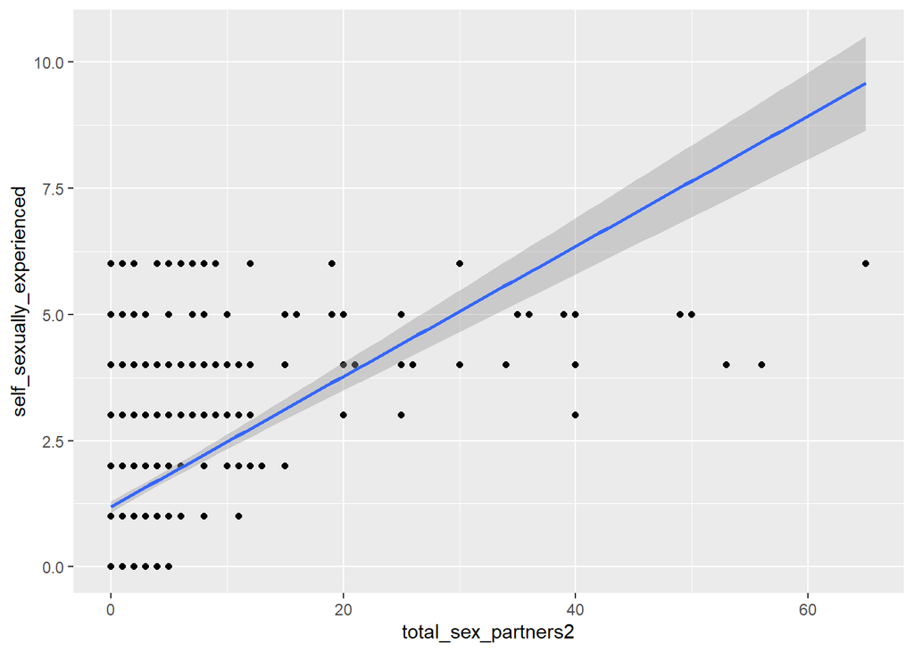

```r
b <- ggplot(data_self_plus_sexual_partner_variable, aes(x = total_sex_partners2, y = self_sexually_experienced))
# Scatter plot with regression line
b + geom_point()+
  geom_smooth(method = "lm")
```

## Relationship options: look at sexual partners variables

```r
# mean
data_rel_plus_sexual_partner_variable %>% group_by(sexual_orientation) %>%
  summarise_at(c("total_sex_partners", "total_sex_partners2"), mean, na.rm = T)
```

```
## # A tibble: 2 x 3
##   sexual_orientation    total_sex_partners total_sex_partners2
##   <chr>                              <dbl>               <dbl>
## 1 Asexual                             1.89                1.90
## 2 Straight/Heterosexual               4.70                4.62
```

```r
# sd
data_rel_plus_sexual_partner_variable %>% group_by(sexual_orientation) %>%
  summarise_at(c("total_sex_partners", "total_sex_partners2"), sd, na.rm = T)
```

```
## # A tibble: 2 x 3
##   sexual_orientation    total_sex_partners total_sex_partners2
##   <chr>                              <dbl>               <dbl>
## 1 Asexual                             5.05                5.14
## 2 Straight/Heterosexual              11.4                 9.81
```

```r
# min
data_rel_plus_sexual_partner_variable %>% group_by(sexual_orientation) %>%
  summarise_at(c("total_sex_partners", "total_sex_partners2"), min, na.rm = T)
```

```
## # A tibble: 2 x 3
##   sexual_orientation    total_sex_partners total_sex_partners2
##   <chr>                              <int>               <dbl>
## 1 Asexual                                0                   0
## 2 Straight/Heterosexual                  0                   0
```

```r
# max
data_rel_plus_sexual_partner_variable %>% group_by(sexual_orientation) %>%
  summarise_at(c("total_sex_partners", "total_sex_partners2"), max, na.rm = T)
```

```
## # A tibble: 2 x 3
##   sexual_orientation    total_sex_partners total_sex_partners2
##   <chr>                              <int>               <dbl>
## 1 Asexual                               50                  53
## 2 Straight/Heterosexual                120                  91
```

```r
# range
data_rel_plus_sexual_partner_variable %>% group_by(sexual_orientation) %>%
  summarise_at(c("total_sex_partners", "total_sex_partners2"), range, na.rm = T)
```

```
## # A tibble: 4 x 3
## # Groups:   sexual_orientation [2]
##   sexual_orientation    total_sex_partners total_sex_partners2
##   <chr>                              <int>               <dbl>
## 1 Asexual                                0                   0
## 2 Asexual                               50                  53
## 3 Straight/Heterosexual                  0                   0
## 4 Straight/Heterosexual                120                  91
```

```r
# median
data_rel_plus_sexual_partner_variable %>% group_by(sexual_orientation) %>%
  summarise_at(c("total_sex_partners", "total_sex_partners2"), median, na.rm = T)
```

```
## # A tibble: 2 x 3
##   sexual_orientation    total_sex_partners total_sex_partners2
##   <chr>                              <dbl>               <dbl>
## 1 Asexual                                0                   0
## 2 Straight/Heterosexual                  1                   1
```

```r
# counts
table(data_rel_plus_sexual_partner_variable$total_sex_partners)
```

```
##
##   0   1   2   3   4   5   6   7   8   9  10  11  12  13  14  15  19  20  21  25
## 275 136  48  35  27  25  10  14  15   5  11   6   3   1   2   5   1   2   1   3
##  30  35  39  40  50  55  70  91 120
##   2   1   1   4   2   1   1   1   1
```

```r
table(data_rel_plus_sexual_partner_variable$total_sex_partners2)
```

```
##
##   0   1   2   3   4   5   6   7   8   9  10  11  12  13  14  15  19  20  21  25
## 275 127  48  41  30  26  11  12  14   5  10   7   4   1   2   4   1   4   1   3
##  30  34  35  39  40  50  52  53  56  65  91
##   1   1   1   1   4   1   1   1   1   1   1
```

## Lifetime sexual partners in unmatched heterosexuals sample

### Load data

```r
data_prefs_unmatched = read.csv(file = "data/data_prefs_unmatched.csv")[,-1]
data_self_unmatched = read.csv(file = "data/data_prefs_unmatched.csv")[,-1]

# add sex partner variable to data
data_prefs_unmatched_plus_sexual_partner_variable = left_join(data_prefs_unmatched, sexual_partner)
data_self_unmatched_plus_sexual_partner_variable = left_join(data_self_unmatched, sexual_partner)
```

### Partner preferences

#### Total number of sex partners

```r
# mean
data_prefs_unmatched_plus_sexual_partner_variable %>% group_by(sexual_orientation) %>%
  summarise_at(c("total_sex_partners", "total_sex_partners2"), mean, na.rm = T)
```

```
## # A tibble: 1 x 3
##   sexual_orientation    total_sex_partners total_sex_partners2
##   <chr>                              <dbl>               <dbl>
## 1 Straight/Heterosexual               6.23        21705628278.
```

```r
# sd
data_prefs_unmatched_plus_sexual_partner_variable %>% group_by(sexual_orientation) %>%
  summarise_at(c("total_sex_partners", "total_sex_partners2"), sd, na.rm = T)
```

```
## # A tibble: 1 x 3
##   sexual_orientation    total_sex_partners total_sex_partners2
##   <chr>                              <dbl>               <dbl>
## 1 Straight/Heterosexual               10.8             4.66e12
```

```r
# min
data_prefs_unmatched_plus_sexual_partner_variable %>% group_by(sexual_orientation) %>%
  summarise_at(c("total_sex_partners", "total_sex_partners2"), min, na.rm = T)
```

```
## # A tibble: 1 x 3
##   sexual_orientation    total_sex_partners total_sex_partners2
##   <chr>                              <int>               <dbl>
## 1 Straight/Heterosexual                  0                   0
```

```r
# max
data_prefs_unmatched_plus_sexual_partner_variable %>% group_by(sexual_orientation) %>%
  summarise_at(c("total_sex_partners", "total_sex_partners2"), max, na.rm = T)
```

```
## # A tibble: 1 x 3
##   sexual_orientation    total_sex_partners total_sex_partners2
##   <chr>                              <int>               <dbl>
## 1 Straight/Heterosexual                200                1e15
```

```r
# range
data_prefs_unmatched_plus_sexual_partner_variable %>% group_by(sexual_orientation) %>%
  summarise_at(c("total_sex_partners", "total_sex_partners2"), range, na.rm = T)
```

```
## # A tibble: 2 x 3
## # Groups:   sexual_orientation [1]
##   sexual_orientation    total_sex_partners total_sex_partners2
##   <chr>                              <int>               <dbl>
## 1 Straight/Heterosexual                  0                0
## 2 Straight/Heterosexual                200                1e15
```

```r
# median
data_prefs_unmatched_plus_sexual_partner_variable %>% group_by(sexual_orientation) %>%
  summarise_at(c("total_sex_partners", "total_sex_partners2"), median, na.rm = T)
```

```
## # A tibble: 1 x 3
##   sexual_orientation    total_sex_partners total_sex_partners2
##   <chr>                              <dbl>               <dbl>
## 1 Straight/Heterosexual                  3                   3
```

```r
# counts
table(data_prefs_unmatched_plus_sexual_partner_variable$total_sex_partners)
```

```
##
##     0     1     2     3     4     5     6     7     8     9    10    11    12
##  6405 10445  5484  4078  2732  2694  1775  1460  1293   711  1755   501   691
##    13    14    15    16    17    18    19    20    21    22    23    24    25
##   356   273  1084   192   179   187    57  1089    90   111    91    40   432
##    26    27    28    29    30    31    32    33    34    35    36    37    38
##    48    39    61    22   525    28    37    25    16   163    16    17    19
##    39    40    41    42    43    44    45    46    47    48    49    50    51
##     4   202     4    13     4     3    50     1     4     5     2   229     4
##    52    53    54    55    56    57    60    61    63    65    66    68    69
##     7     9     3    19     3     1    67     2     2     8     1     5     1
##    70    73    74    75    77    78    80    84    85    86    88    89    90
##    29     1     1    10     1     3    39     1     2     1     1     2     7
##    91    97    99   100   107   110   113   115   120   125   130   136   150
##     1     1     1    74     1     1     1     1     8     1     1     1    14
##   170   174   175   176   200
##     1     1     1     1    12
```

```r
table(data_prefs_unmatched_plus_sexual_partner_variable$total_sex_partners2)
```

```
##
##      0      1      2      3      4      5      6      7      8      9     10
##   6257  10304   5508   4040   2747   2630   1834   1518   1330    775   1553
##     11     12     13     14     15     16     17     18     19     20     21
##    586    747    435    297   1011    223    210    248     84    871    106
##     22     23     24     25     26     27     28     29     30     31     32
##    136    111     47    444     56     49     80     29    493     33     52
##     33     34     35     36     37     38     39     40     41     42     43
##     26     19    169     20     22     32      7    201      5     17      6
##     44     45     46     47     48     49     50     51     52     53     54
##      4     60      3      4      7      4    199      5      9     12      5
##     55     56     57     58     60     61     62     63     64     65     68
##     25      1      1      3     70      2      1      4      1     13      4
##     69     70     73     74     75     77     78     80     81     82     84
##      2     30      2      1     12      1      4     42      2      1      1
##     85     86     88     89     90     91     93     95     97     98    100
##      1      1      1      1     11      1      1      3      1      1     56
##    101    102    107    110    113    115    120    125    130    136    150
##      1      1      1      6      1      2     12      4      4      1     16
##    170    175    176    189    200    210    230    245    250    300    400
##      1      1      1      1     16      1      1      1      2      4      4
##    500    600    800   1500  10000 102875  1e+15
##      1      1      2      1      1      1      1
```

Using variable total_sex_partners as total_sex_partners2 seems to have unreasonably high values. Mean number of lifetime sexual partners in unmatched heterosexual sample is 6.23.

### Self-ratings

#### Total number of sex partners

```r
# mean
data_self_unmatched_plus_sexual_partner_variable %>% group_by(sexual_orientation) %>%
  summarise_at(c("total_sex_partners", "total_sex_partners2"), mean, na.rm = T)
```

```
## # A tibble: 1 x 3
##   sexual_orientation    total_sex_partners total_sex_partners2
##   <chr>                              <dbl>               <dbl>
## 1 Straight/Heterosexual               6.23        21705628278.
```

```r
# sd
data_self_unmatched_plus_sexual_partner_variable %>% group_by(sexual_orientation) %>%
  summarise_at(c("total_sex_partners", "total_sex_partners2"), sd, na.rm = T)
```

```
## # A tibble: 1 x 3
##   sexual_orientation    total_sex_partners total_sex_partners2
##   <chr>                              <dbl>               <dbl>
## 1 Straight/Heterosexual               10.8             4.66e12
```

```r
# min
data_self_unmatched_plus_sexual_partner_variable %>% group_by(sexual_orientation) %>%
  summarise_at(c("total_sex_partners", "total_sex_partners2"), min, na.rm = T)
```

```
## # A tibble: 1 x 3
##   sexual_orientation    total_sex_partners total_sex_partners2
##   <chr>                              <int>               <dbl>
## 1 Straight/Heterosexual                  0                   0
```

```r
# max
data_self_unmatched_plus_sexual_partner_variable %>% group_by(sexual_orientation) %>%
  summarise_at(c("total_sex_partners", "total_sex_partners2"), max, na.rm = T)
```

```
## # A tibble: 1 x 3
##   sexual_orientation    total_sex_partners total_sex_partners2
##   <chr>                              <int>               <dbl>
## 1 Straight/Heterosexual                200                1e15
```

```r
# range
data_self_unmatched_plus_sexual_partner_variable %>% group_by(sexual_orientation) %>%
  summarise_at(c("total_sex_partners", "total_sex_partners2"), range, na.rm = T)
```

```
## # A tibble: 2 x 3
## # Groups:   sexual_orientation [1]
##   sexual_orientation    total_sex_partners total_sex_partners2
##   <chr>                              <int>               <dbl>
## 1 Straight/Heterosexual                  0                0
## 2 Straight/Heterosexual                200                1e15
```

```r
# median
data_self_unmatched_plus_sexual_partner_variable %>% group_by(sexual_orientation) %>%
  summarise_at(c("total_sex_partners", "total_sex_partners2"), median, na.rm = T)
```

```
## # A tibble: 1 x 3
##   sexual_orientation    total_sex_partners total_sex_partners2
##   <chr>                              <dbl>               <dbl>
## 1 Straight/Heterosexual                  3                   3
```

```r
# counts
table(data_self_unmatched_plus_sexual_partner_variable$total_sex_partners)
```

```
##
##     0     1     2     3     4     5     6     7     8     9    10    11    12
##  6405 10445  5484  4078  2732  2694  1775  1460  1293   711  1755   501   691
##    13    14    15    16    17    18    19    20    21    22    23    24    25
##   356   273  1084   192   179   187    57  1089    90   111    91    40   432
##    26    27    28    29    30    31    32    33    34    35    36    37    38
##    48    39    61    22   525    28    37    25    16   163    16    17    19
##    39    40    41    42    43    44    45    46    47    48    49    50    51
##     4   202     4    13     4     3    50     1     4     5     2   229     4
##    52    53    54    55    56    57    60    61    63    65    66    68    69
##     7     9     3    19     3     1    67     2     2     8     1     5     1
##    70    73    74    75    77    78    80    84    85    86    88    89    90
##    29     1     1    10     1     3    39     1     2     1     1     2     7
##    91    97    99   100   107   110   113   115   120   125   130   136   150
##     1     1     1    74     1     1     1     1     8     1     1     1    14
##   170   174   175   176   200
##     1     1     1     1    12
```

```r
table(data_self_unmatched_plus_sexual_partner_variable$total_sex_partners2)
```

```
##
##      0      1      2      3      4      5      6      7      8      9     10
##   6257  10304   5508   4040   2747   2630   1834   1518   1330    775   1553
##     11     12     13     14     15     16     17     18     19     20     21
##    586    747    435    297   1011    223    210    248     84    871    106
##     22     23     24     25     26     27     28     29     30     31     32
##    136    111     47    444     56     49     80     29    493     33     52
##     33     34     35     36     37     38     39     40     41     42     43
##     26     19    169     20     22     32      7    201      5     17      6
##     44     45     46     47     48     49     50     51     52     53     54
##      4     60      3      4      7      4    199      5      9     12      5
##     55     56     57     58     60     61     62     63     64     65     68
##     25      1      1      3     70      2      1      4      1     13      4
##     69     70     73     74     75     77     78     80     81     82     84
##      2     30      2      1     12      1      4     42      2      1      1
##     85     86     88     89     90     91     93     95     97     98    100
##      1      1      1      1     11      1      1      3      1      1     56
##    101    102    107    110    113    115    120    125    130    136    150
##      1      1      1      6      1      2     12      4      4      1     16
##    170    175    176    189    200    210    230    245    250    300    400
##      1      1      1      1     16      1      1      1      2      4      4
##    500    600    800   1500  10000 102875  1e+15
##      1      1      2      1      1      1      1
```

Using variable total_sex_partners as total_sex_partners2 seems to have unreasonably high values. Mean number of lifetime sexual partners in unmatched heterosexual sample is 6.23.